# IODS course project

# Exercise 3 (Logistic regression)

Exercice 3 analysis

### 3.2 Read Data

Start by reading the dataset and looking up the variable names

```r
alc <- read.table("http://s3.amazonaws.com/assets.datacamp.com/production/course_2218/datasets/alc.txt", header=TRUE,  sep = ",")
colnames(alc)
```

```
##  [1] "school"     "sex"        "age"        "address"    "famsize"
##  [6] "Pstatus"    "Medu"       "Fedu"       "Mjob"       "Fjob"
## [11] "reason"     "nursery"    "internet"   "guardian"   "traveltime"
## [16] "studytime"  "failures"   "schoolsup"  "famsup"     "paid"
## [21] "activities" "higher"     "romantic"   "famrel"     "freetime"
## [26] "goout"      "Dalc"       "Walc"       "health"     "absences"
## [31] "G1"         "G2"         "G3"         "alc_use"    "high_use"
```

The dataset describes students in two Portuguese schools. Each observation describes a single student, including their age, gender, performance at school. For this exercise we’ll be mainly looking at alcohol consumption.

### 3.4 Hypotheses about alcohol use

Specifically, we’ll examine the relationship between high alcohol consumption and final student grades (G3), family relationship (famrel), absences, and age.

Intuitively we would expect high alcohol use to correlate with worse grades, possibly worse family relationships, more absences and higher age.

Lets look at grades first.

### 3.5 Exploration

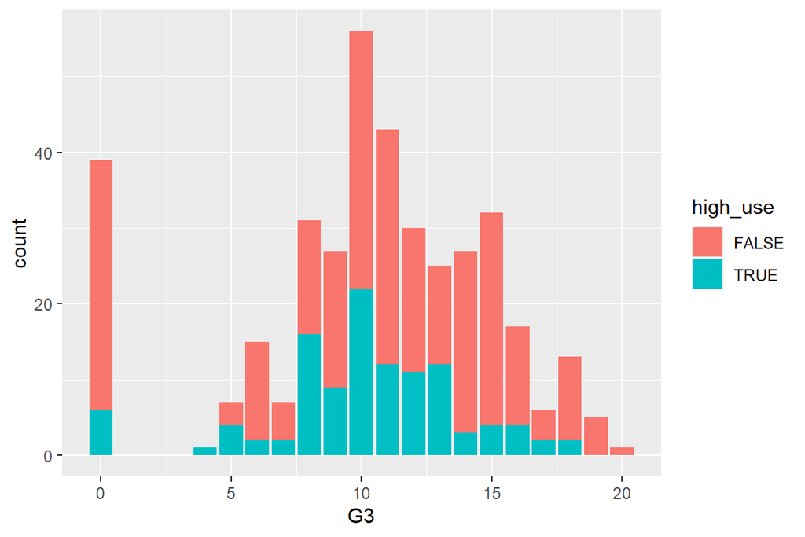

```r
ggplot(data = alc, aes(x = G3, fill = high_use)) + geom_bar()
```

```r
table(highuse = alc$high_use, grades = alc$G3)
```

```
##        grades
## highuse  0  4  5  6  7  8  9 10 11 12 13 14 15 16 17 18 19 20
##   FALSE 33  0  3 13  5 15 18 34 31 19 13 24 28 13  4 11  5  1
##   TRUE   6  1  4  2  2 16  9 22 12 11 12  3  4  4  2  2  0  0
```

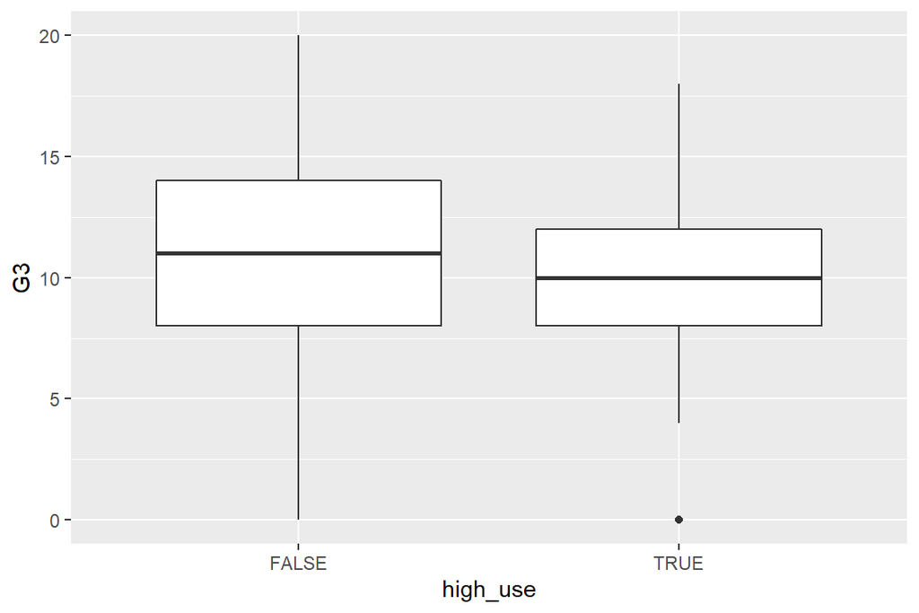

```r
ggplot(alc, aes(x = high_use, y = G3)) + geom_boxplot()
```

Students with the highest grades seem to mostly be in the lower use category.

Let’s look at family support next.

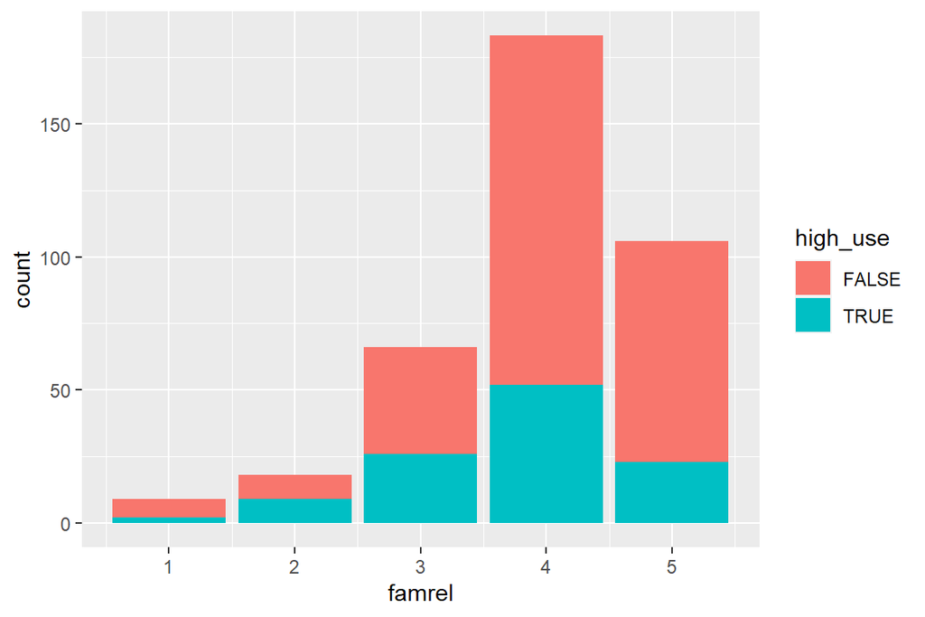

```r
ggplot(data = alc, aes(x = famrel, fill = high_use)) + geom_bar()
```

```r
table(highuse = alc$high_use, family = alc$famrel)
```

```
##        family
## highuse   1   2   3   4   5
##   FALSE   7   9  40 131  83
##   TRUE    2   9  26  52  23
```

```r
for (i in sort(unique(alc$famrel))) {
  sub = alc[alc$famrel==i,]
  high = sum(sub$high_use==TRUE)
  low = sum(sub$high_use==FALSE)
  ratio = round(high/(low + high)*100, digits = 2)
  print(paste(toString(ratio), "% of students with a family relationship of", toString(i), "are in the high alcohol category."))

}
```

```
## [1] "22.22 % of students with a family relationship of 1 are in the high alcohol category."
## [1] "50 % of students with a family relationship of 2 are in the high alcohol category."
## [1] "39.39 % of students with a family relationship of 3 are in the high alcohol category."
## [1] "28.42 % of students with a family relationship of 4 are in the high alcohol category."
## [1] "21.7 % of students with a family relationship of 5 are in the high alcohol category."
```

It certainly looks like a high family relationship predicts a lower use of alcohol (at least when famrel >= 2. Relatively low number samples in the famrel == 1 category might explain the low ration of high alcohol consumption).

Then absences.

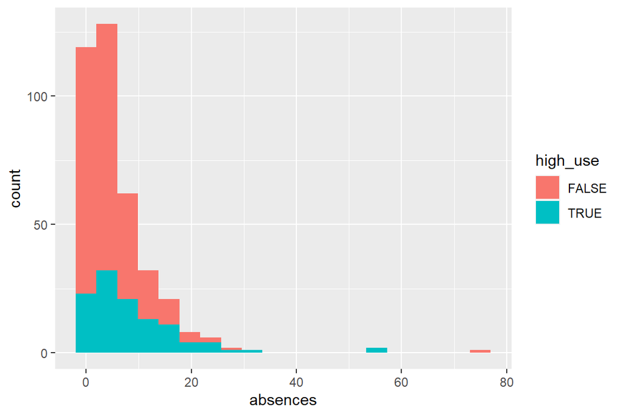

```r
ggplot(data = alc, aes(x = absences, fill = high_use)) + geom_histogram(bins = 20)
```

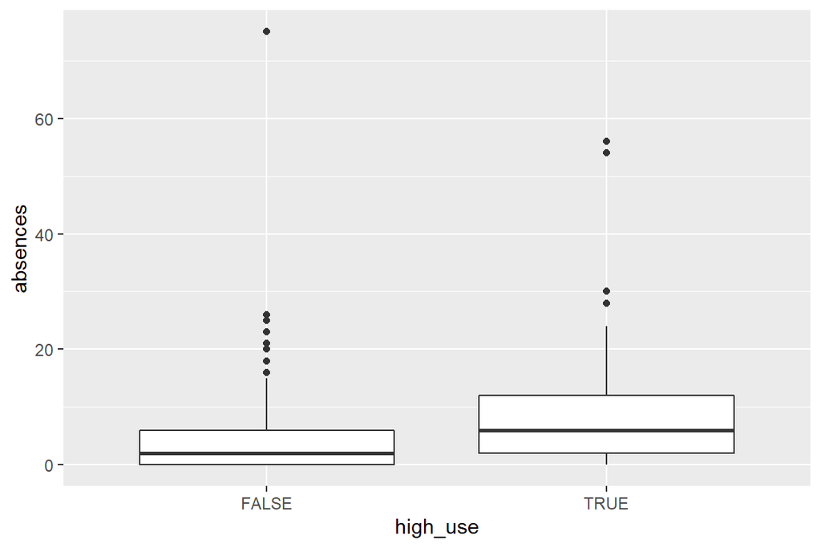

```r
ggplot(alc, aes(x = high_use, y = absences)) + geom_boxplot()
```

Hmm… A bit hard to make out, but it looks like those with more absences are more likely to be in the high use category.

Finally,lets look at age

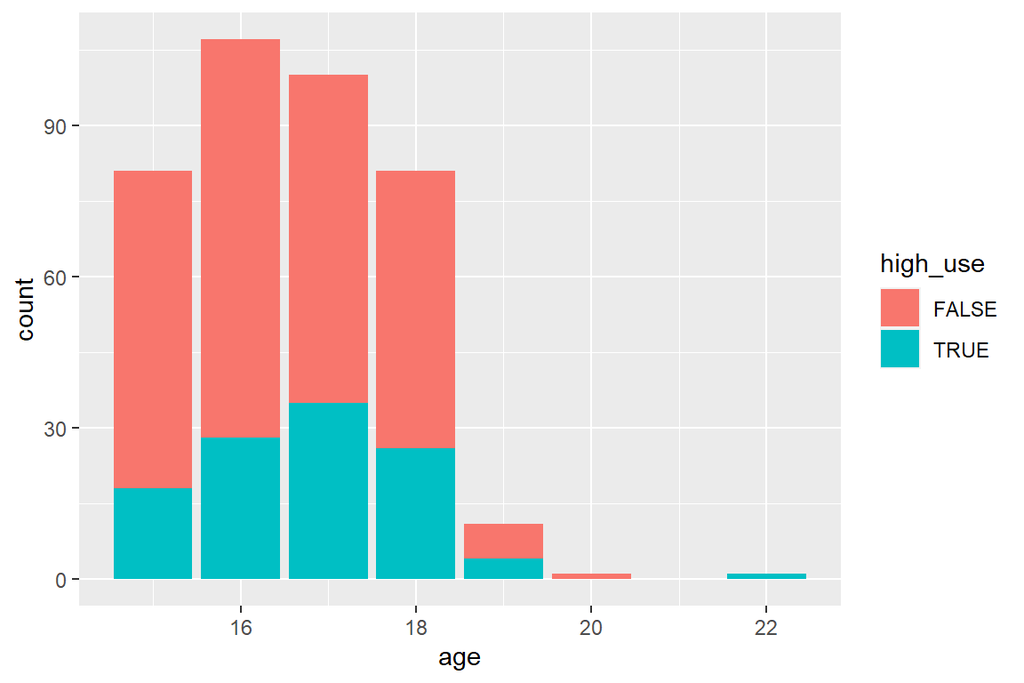

```r
ggplot(data = alc, aes(x = age, fill = high_use)) + geom_bar()
```

```r
table(highuse = alc$high_use, age = alc$age)
```

```
##        age
## highuse 15 16 17 18 19 20 22
##   FALSE 63 79 65 55  7  1  0
##   TRUE  18 28 35 26  4  0  1
```

```r
for (i in sort(unique(alc$age))) {
  sub = alc[alc$age==i,]
  high = sum(sub$high_use==TRUE)
  low = sum(sub$high_use==FALSE)
  ratio = round(high/(low + high)*100, digits = 2)
  print(paste(toString(ratio), "% of students of the age of", toString(i), "are in the high alcohol category."))

}
```

```
## [1] "22.22 % of students of the age of 15 are in the high alcohol category."
## [1] "26.17 % of students of the age of 16 are in the high alcohol category."
## [1] "35 % of students of the age of 17 are in the high alcohol category."
## [1] "32.1 % of students of the age of 18 are in the high alcohol category."
## [1] "36.36 % of students of the age of 19 are in the high alcohol category."
## [1] "0 % of students of the age of 20 are in the high alcohol category."
## [1] "100 % of students of the age of 22 are in the high alcohol category."
```

It looks like alcohol consumption somewhat jumps up at at the age 17 and above.

### 3.5 Logistic Regression

```r
logreg <- glm(high_use ~ G3 + famrel + absences + age, data = alc, family = "binomial")
summary(logreg)
```

```
##
## Call:
## glm(formula = high_use ~ G3 + famrel + absences + age, family = "binomial",
##     data = alc)
##
## Deviance Residuals:
##     Min       1Q   Median       3Q      Max
## -2.7108  -0.8076  -0.6780   1.2143   1.9825
##
## Coefficients:
##              Estimate Std. Error z value Pr(>|z|)
## (Intercept) -2.645322   1.795231  -1.474 0.140609
## G3          -0.009729   0.025802  -0.377 0.706121
## famrel      -0.277364   0.122979  -2.255 0.024110 *
## absences     0.062522   0.017618   3.549 0.000387 ***
## age          0.155649   0.102233   1.522 0.127887
## ---
## Signif. codes:  0 '***' 0.001 '**' 0.01 '*' 0.05 '.' 0.1 ' ' 1
##
## (Dispersion parameter for binomial family taken to be 1)
##
##     Null deviance: 462.21  on 381  degrees of freedom
## Residual deviance: 436.02  on 377  degrees of freedom
## AIC: 446.02
##
## Number of Fisher Scoring iterations: 4
```

Both family relationship and absences have a significant effect. Neither age or grades have a significant effect.

Let’s look at the odd ratios and their 95% confidence intervals.

```r
exp(cbind(coef(logreg), confint(logreg)))
```

```
##                              2.5 %    97.5 %
## (Intercept) 0.07098251 0.002037894 2.3734971
## G3          0.99031793 0.941826103 1.0423755
## famrel      0.75777871 0.594401560 0.9644452
## absences    1.06451794 1.030446671 1.1039063
## age         1.16841640 0.956650325 1.4300500
```

In summary, the model supports our hypotheses about absences and family relationships, but not grades or age.

### 3.5 Predictive power of the model

Let’s explore the predictive power of the model

```r
prob <- predict(logreg, type = "response")

alc <- mutate(alc, probability = prob)
alc <- mutate(alc, prediction = prob > 0.5)
table(high_use = alc$high_use, prediction = alc$prediction)
```

```
##         prediction
## high_use FALSE TRUE
##    FALSE   260   10
##    TRUE     98   14
```

The training error is (98 + 10)/382 = 0.283 with most errors being false negatives. This is certainly better than guessing at 50% probability, but given that only about 30% of students are in the high alcohol use category are in the first place, it’s actually not all that much better than just assuming that a student is in the low-alcohol consumption group.

# Exercise 4 (Clustering and classification)

Exercice 4 analysis

Let’s start by loading the data and looking at its structure.

## 4.2 Loading and exploring the dataset

```r
library(MASS)

data(Boston)
str(Boston)
```

```
## 'data.frame':    506 obs. of  14 variables:
##  $ crim   : num  0.00632 0.02731 0.02729 0.03237 0.06905 ...
##  $ zn     : num  18 0 0 0 0 0 12.5 12.5 12.5 12.5 ...
##  $ indus  : num  2.31 7.07 7.07 2.18 2.18 2.18 7.87 7.87 7.87 7.87 ...
##  $ chas   : int  0 0 0 0 0 0 0 0 0 0 ...
##  $ nox    : num  0.538 0.469 0.469 0.458 0.458 0.458 0.524 0.524 0.524 0.524 ...
##  $ rm     : num  6.58 6.42 7.18 7 7.15 ...
##  $ age    : num  65.2 78.9 61.1 45.8 54.2 58.7 66.6 96.1 100 85.9 ...
##  $ dis    : num  4.09 4.97 4.97 6.06 6.06 ...
##  $ rad    : int  1 2 2 3 3 3 5 5 5 5 ...
##  $ tax    : num  296 242 242 222 222 222 311 311 311 311 ...
##  $ ptratio: num  15.3 17.8 17.8 18.7 18.7 18.7 15.2 15.2 15.2 15.2 ...
##  $ black  : num  397 397 393 395 397 ...
##  $ lstat  : num  4.98 9.14 4.03 2.94 5.33 ...
##  $ medv   : num  24 21.6 34.7 33.4 36.2 28.7 22.9 27.1 16.5 18.9 ...
```

The dataset regards housing values in different towns of the Boston metropolitan area. It has 506 observations with 14 variables including the median value of owner-occupied homes in the town (medev), the per capita crime rate of the town (crim), and proportion of non-retail business acres per town (indus). The descriptions for all the variables can be found on [here](http://alumni.media.mit.edu/~tpminka/courses/36-350.2001/hw/hw7/Boston.html).

## 4.3 Graphical overview and summary of the data

Let’s plot a correlation matrix to visualize possible correlations between variables.

```r
#load the libraries
library(corrplot)
library(tidyverse)

#generate and plot correlation matrices
corr_matrix <- cor(Boston)
corr_matrix %>% round(digits = 2)
```

```
##          crim    zn indus  chas   nox    rm   age   dis   rad   tax ptratio
## crim     1.00 -0.20  0.41 -0.06  0.42 -0.22  0.35 -0.38  0.63  0.58    0.29
## zn      -0.20  1.00 -0.53 -0.04 -0.52  0.31 -0.57  0.66 -0.31 -0.31   -0.39
## indus    0.41 -0.53  1.00  0.06  0.76 -0.39  0.64 -0.71  0.60  0.72    0.38
## chas    -0.06 -0.04  0.06  1.00  0.09  0.09  0.09 -0.10 -0.01 -0.04   -0.12
## nox      0.42 -0.52  0.76  0.09  1.00 -0.30  0.73 -0.77  0.61  0.67    0.19
## rm      -0.22  0.31 -0.39  0.09 -0.30  1.00 -0.24  0.21 -0.21 -0.29   -0.36
## age      0.35 -0.57  0.64  0.09  0.73 -0.24  1.00 -0.75  0.46  0.51    0.26
## dis     -0.38  0.66 -0.71 -0.10 -0.77  0.21 -0.75  1.00 -0.49 -0.53   -0.23
## rad      0.63 -0.31  0.60 -0.01  0.61 -0.21  0.46 -0.49  1.00  0.91    0.46
## tax      0.58 -0.31  0.72 -0.04  0.67 -0.29  0.51 -0.53  0.91  1.00    0.46
## ptratio  0.29 -0.39  0.38 -0.12  0.19 -0.36  0.26 -0.23  0.46  0.46    1.00
## black   -0.39  0.18 -0.36  0.05 -0.38  0.13 -0.27  0.29 -0.44 -0.44   -0.18
## lstat    0.46 -0.41  0.60 -0.05  0.59 -0.61  0.60 -0.50  0.49  0.54    0.37
## medv    -0.39  0.36 -0.48  0.18 -0.43  0.70 -0.38  0.25 -0.38 -0.47   -0.51
##         black lstat  medv
## crim    -0.39  0.46 -0.39
## zn       0.18 -0.41  0.36
## indus   -0.36  0.60 -0.48
## chas     0.05 -0.05  0.18
## nox     -0.38  0.59 -0.43
## rm       0.13 -0.61  0.70
## age     -0.27  0.60 -0.38
## dis      0.29 -0.50  0.25
## rad     -0.44  0.49 -0.38
## tax     -0.44  0.54 -0.47
## ptratio -0.18  0.37 -0.51
## black    1.00 -0.37  0.33
## lstat   -0.37  1.00 -0.74
## medv     0.33 -0.74  1.00
```

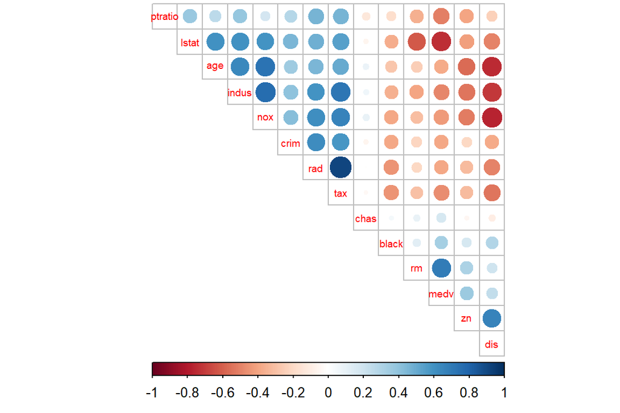

```r
corrplot(corr_matrix, method="circle", type = "upper", cl.pos = "b", , order = "hclus", tl.pos = "d", tl.cex = 0.6)
```

We can see some strong positive correlations including tax-tad, tax-indus, nox-indus, and nox-age. Strong negative correlations include: dis-nox, dis-indus, dis-age, and medv-lstat.

For example if look at nox and dis, we can see a clear relationship.

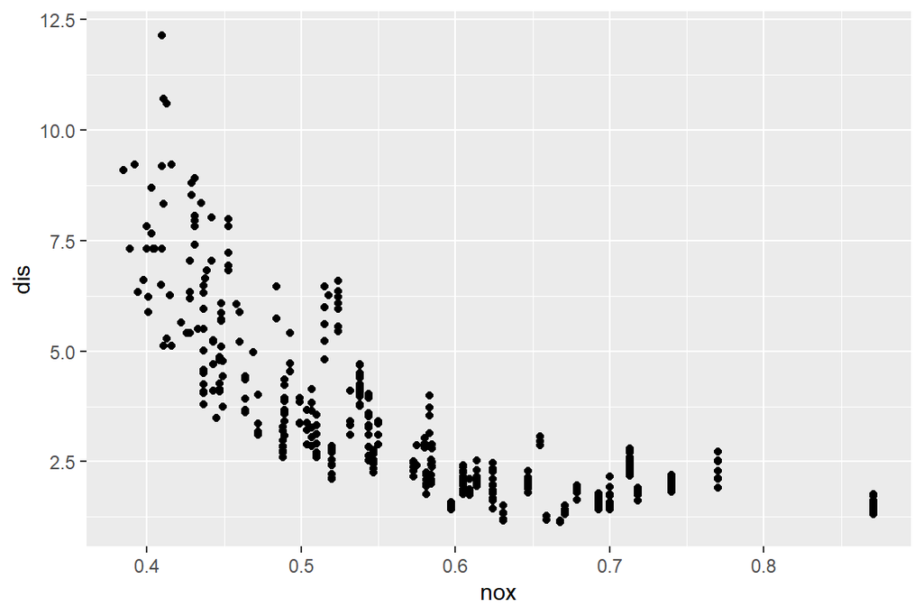

```r
ggplot(data = Boston, aes(x = nox, y = dis)) + geom_point()
```

Now, let’s look at the summary.

```r
summary(Boston)
```

```
##       crim                zn             indus            chas
##  Min.   : 0.00632   Min.   :  0.00   Min.   : 0.46   Min.   :0.00000
##  1st Qu.: 0.08205   1st Qu.:  0.00   1st Qu.: 5.19   1st Qu.:0.00000
##  Median : 0.25651   Median :  0.00   Median : 9.69   Median :0.00000
##  Mean   : 3.61352   Mean   : 11.36   Mean   :11.14   Mean   :0.06917
##  3rd Qu.: 3.67708   3rd Qu.: 12.50   3rd Qu.:18.10   3rd Qu.:0.00000
##  Max.   :88.97620   Max.   :100.00   Max.   :27.74   Max.   :1.00000
##       nox               rm             age              dis
##  Min.   :0.3850   Min.   :3.561   Min.   :  2.90   Min.   : 1.130
##  1st Qu.:0.4490   1st Qu.:5.886   1st Qu.: 45.02   1st Qu.: 2.100
##  Median :0.5380   Median :6.208   Median : 77.50   Median : 3.207
##  Mean   :0.5547   Mean   :6.285   Mean   : 68.57   Mean   : 3.795
##  3rd Qu.:0.6240   3rd Qu.:6.623   3rd Qu.: 94.08   3rd Qu.: 5.188
##  Max.   :0.8710   Max.   :8.780   Max.   :100.00   Max.   :12.127
##       rad              tax           ptratio          black
##  Min.   : 1.000   Min.   :187.0   Min.   :12.60   Min.   :  0.32
##  1st Qu.: 4.000   1st Qu.:279.0   1st Qu.:17.40   1st Qu.:375.38
##  Median : 5.000   Median :330.0   Median :19.05   Median :391.44
##  Mean   : 9.549   Mean   :408.2   Mean   :18.46   Mean   :356.67
##  3rd Qu.:24.000   3rd Qu.:666.0   3rd Qu.:20.20   3rd Qu.:396.23
##  Max.   :24.000   Max.   :711.0   Max.   :22.00   Max.   :396.90
##      lstat            medv
##  Min.   : 1.73   Min.   : 5.00
##  1st Qu.: 6.95   1st Qu.:17.02
##  Median :11.36   Median :21.20
##  Mean   :12.65   Mean   :22.53
##  3rd Qu.:16.95   3rd Qu.:25.00
##  Max.   :37.97   Max.   :50.00
```

We can see that there’s quite a bit of range in regards to many of the variables. Median value of owner-occupied homes for example varies from $5000 to $50000 (we can see that the dataset is rather old considering how low the prices area).

## 4.4 Standardize the dataset

Let’s standardize the dataset with the scale function

```r
scaled_data <- scale(Boston)
scaled_data <- as.data.frame(scaled_data)

summary(scaled_data)
```

```
##       crim                 zn               indus              chas
##  Min.   :-0.419367   Min.   :-0.48724   Min.   :-1.5563   Min.   :-0.2723
##  1st Qu.:-0.410563   1st Qu.:-0.48724   1st Qu.:-0.8668   1st Qu.:-0.2723
##  Median :-0.390280   Median :-0.48724   Median :-0.2109   Median :-0.2723
##  Mean   : 0.000000   Mean   : 0.00000   Mean   : 0.0000   Mean   : 0.0000
##  3rd Qu.: 0.007389   3rd Qu.: 0.04872   3rd Qu.: 1.0150   3rd Qu.:-0.2723
##  Max.   : 9.924110   Max.   : 3.80047   Max.   : 2.4202   Max.   : 3.6648
##       nox                rm               age               dis
##  Min.   :-1.4644   Min.   :-3.8764   Min.   :-2.3331   Min.   :-1.2658
##  1st Qu.:-0.9121   1st Qu.:-0.5681   1st Qu.:-0.8366   1st Qu.:-0.8049
##  Median :-0.1441   Median :-0.1084   Median : 0.3171   Median :-0.2790
##  Mean   : 0.0000   Mean   : 0.0000   Mean   : 0.0000   Mean   : 0.0000
##  3rd Qu.: 0.5981   3rd Qu.: 0.4823   3rd Qu.: 0.9059   3rd Qu.: 0.6617
##  Max.   : 2.7296   Max.   : 3.5515   Max.   : 1.1164   Max.   : 3.9566
##       rad               tax             ptratio            black
##  Min.   :-0.9819   Min.   :-1.3127   Min.   :-2.7047   Min.   :-3.9033
##  1st Qu.:-0.6373   1st Qu.:-0.7668   1st Qu.:-0.4876   1st Qu.: 0.2049
##  Median :-0.5225   Median :-0.4642   Median : 0.2746   Median : 0.3808
##  Mean   : 0.0000   Mean   : 0.0000   Mean   : 0.0000   Mean   : 0.0000
##  3rd Qu.: 1.6596   3rd Qu.: 1.5294   3rd Qu.: 0.8058   3rd Qu.: 0.4332
##  Max.   : 1.6596   Max.   : 1.7964   Max.   : 1.6372   Max.   : 0.4406
##      lstat              medv
##  Min.   :-1.5296   Min.   :-1.9063
##  1st Qu.:-0.7986   1st Qu.:-0.5989
##  Median :-0.1811   Median :-0.1449
##  Mean   : 0.0000   Mean   : 0.0000
##  3rd Qu.: 0.6024   3rd Qu.: 0.2683
##  Max.   : 3.5453   Max.   : 2.9865
```

What we’ve done is scale each variable by subtracting the mean from each value and dividing by the standard deviation. This means that the mean of each variable is set to 0 and each value tells us how many standard deviations away from 0 the value is.

Now, let’s create a categorical variable of the crime rate.

```r
bins <- quantile(scaled_data$crim)
crime <- cut(scaled_data$crim, breaks = bins, labels = c("low","med_low","med_high","high"), include.lowest = TRUE)

table(crime)
```

```
## crime
##      low  med_low med_high     high
##      127      126      126      127
```

Now, let’s replace the old crim variable with the new one.

```r
scaled_data <- dplyr::select(scaled_data, -crim)
scaled_data <- data.frame(scaled_data, crime)
```

```r
ind <- sample(nrow(scaled_data), size = nrow(scaled_data)*0.8)
train <- scaled_data[ind,]
test <- scaled_data
```

## 4.5 Fit the LDA

Let’s fit linear discriminant analysis (LDA) using the training set with our new categorial crime variable as the target variable.

```r
lda_fit <- lda(crime ~ ., data = train)
```

Now let’s visualize the LDA with a biplot.

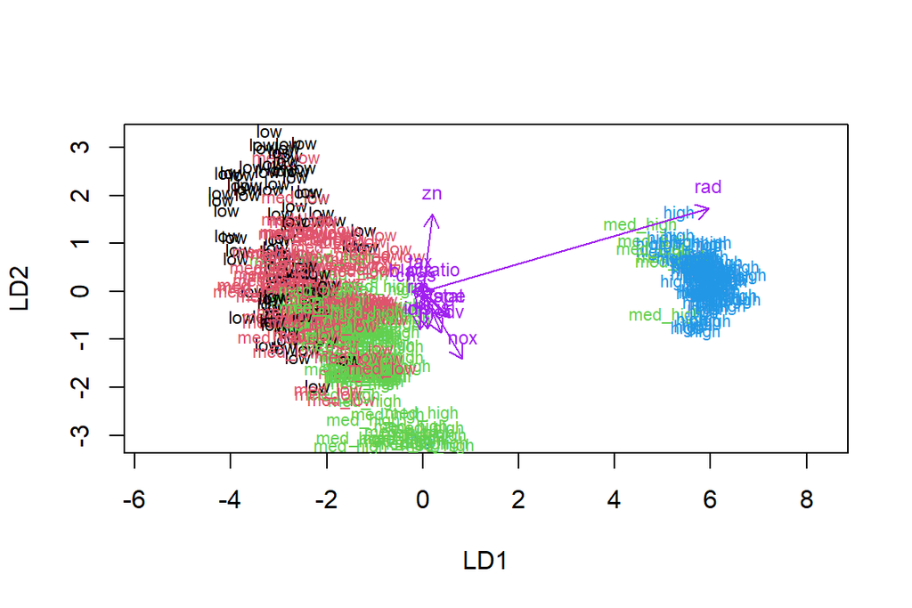

```r
lda.arrows <- function(x, myscale = 1, arrow.heads = 0.1, color = 'purple', tex = 0.75, choices = c(1,2)) {
  heads = coef(x)
  arrows(x0 = 0, y0 = 0,
         x1 = myscale*heads[,choices[1]],
         y1 = myscale*heads[,choices[2]],
         col = color, length = arrow.heads)
  text(myscale*heads[,choices], labels = row.names(heads), cex = tex, col = color, pos = 3)
}
classes = as.numeric(train$crime)

plot(lda_fit, dimen = 2, col = classes)
lda.arrows(lda_fit, myscale = 2)
```

## 4.6 Predicting the classes

First, let’s save and remove the crime variable from the test set.

```r
correct <- test$crime
test <- dplyr::select(test, -crime)
```

Now, let’s predict

```r
predictions <- predict(lda_fit, newdata = test)
t <- table(correct = correct, predicted = predictions$class)
t
```

```
##           predicted
## correct    low med_low med_high high
##   low       69      52        6    0
##   med_low   16      96       14    0
##   med_high   2      47       71    6
##   high       0       0        1  126
```

The high class is predicted very well, but low is quite often mistaken as med_low and med_high as med_low. Still, the model seems quite reasonable; almost all of the errors seem are one category away from the real class.

## 4.7 K-means algorithm

Let’s reload the dataset, standardize it and calculate the distances between observations.

```r
data(Boston)
scaled_data <- scale(Boston)
dist <- dist(scaled_data)
```

Let’s first just run a k-means algorithm with 3 clusters.

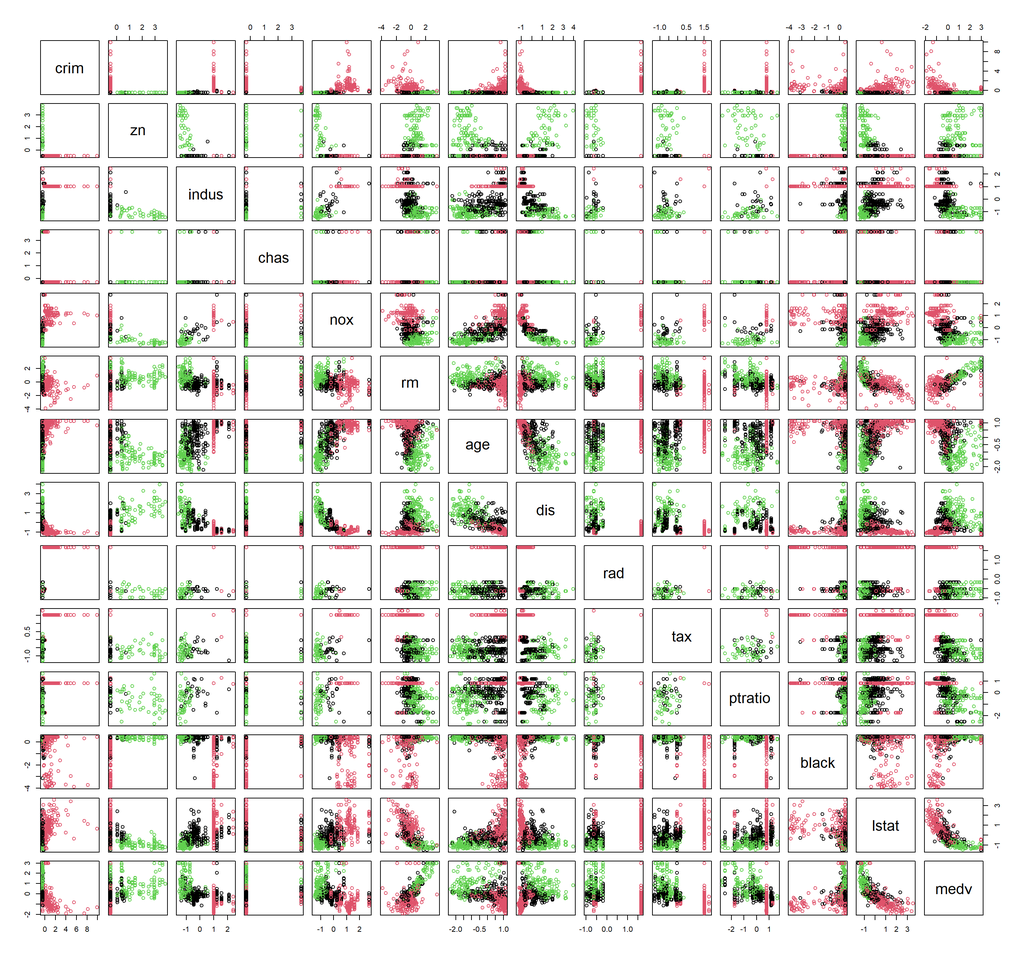

```r
km <-kmeans(scaled_data, centers = 3)
pairs(scaled_data, col = km$cluster)
```

Hmm… can’t make too much sense out of the clusters with this visualization. Let’s get back to this later.

Now, let’s try to figure out how many clusters we should optimally use by looking at how WCSS (within cluster sum of squares) behaves when we change the number of clusters.

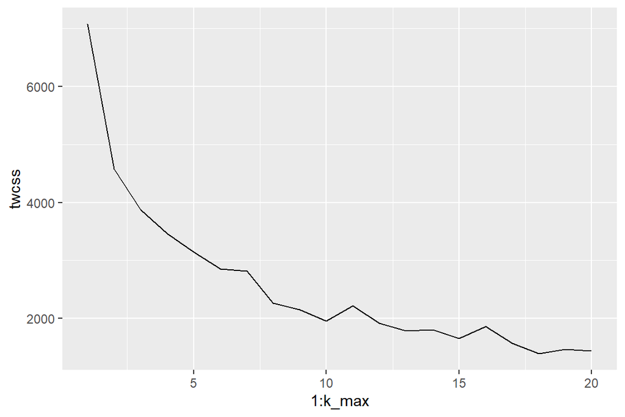

```r
library(ggplot2)

set.seed(123)

k_max <- 20
twcss <- sapply(1:k_max, function(k){kmeans(scaled_data, k)$tot.withinss})

qplot(x = 1:k_max, y = twcss, geom = 'line')
```

Based on the big drop around 2, let’s use 2 as our number of klusters.

Now let’s run our k-means algorithm.

```r
km <-kmeans(scaled_data, centers = 2)
scaled_data <- as.data.frame(cbind(scaled_data, km$cluster))
```

Now let’s visualize the clusters.

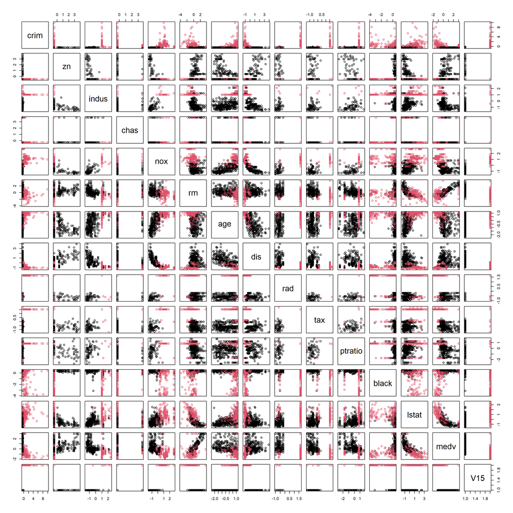

```r
pairs(scaled_data, col = km$cluster)
```

It’s a little hard to make out. Let’s try another way to visualize the clusters.

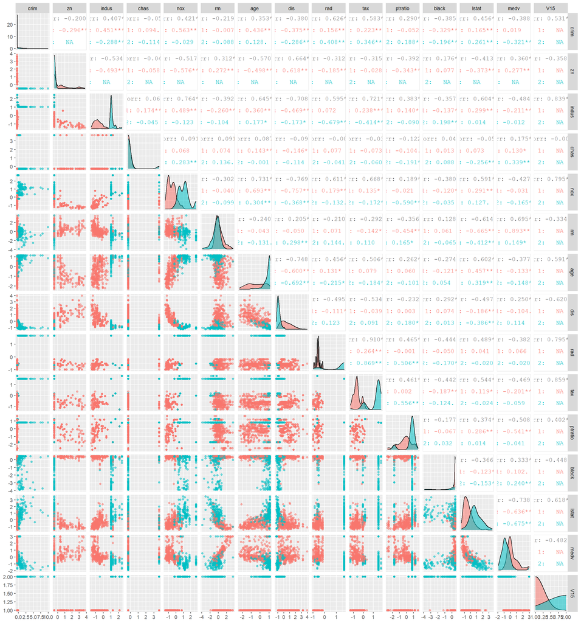

```r
library(GGally)

scaled_data <- data.frame(scaled_data)
ggpairs(scaled_data, aes(col = as.factor(km$cluster), alpha = 0.3), lower = list(combo = wrap("facethist", bins = 20)))
```

The clusters appear rather distinct now. Blue cluster seems to include mostly towns that have more industry, higher accessibility to highways, higher taxes, have worse air quality (nox), have lower status population, are closer to the Boston employment centers and have lower-valued homes.

(more chapters to be added similarly as we proceed with the course!)